# Testing code differential expression

# Info

# Install libraries

```r
# Tidyverse
install.packages("tidyverse")
```

```
Error in install.packages : Updating loaded packages
```

```r
# DESeq
if (!requireNamespace("BiocManager", quietly = TRUE))
    install.packages("BiocManager")

BiocManager::install("DESeq")
install.packages("tidyverse")
#ggplot2
install.packages("ggplot2")
```

```
Error in install.packages : Updating loaded packages
```

```r
# Farver
install.packages("farver")
```

```
Error in install.packages : Updating loaded packages
```

```r
# VennDiagram package
install.packages("VennDiagram")
```

```
Error in install.packages : Updating loaded packages
```

# Import libraries needed

```r
library("DESeq")
library("ggplot2")
library("tidyverse")
library(VennDiagram) # to make venn diagrammes from DE genes
library(RColorBrewer) # coloring Venn diagrammes
```

# Load the data

Data from the mapping were loaded, then processed to remove the sense/antisense counts and only keep the total ones.

```r
# time = 0h
counts_0h = read.table('/home/student5/project/mapping/mapping_2020_02_24/count_values/counts_values_0h.txt',
                       sep = "\t", row.names = 1, header = TRUE)
colnames_0h_samples = str_remove(colnames(counts_0h)[1:3],".sorted.bam") # keep the first 3 names
colnames_0h_samples = paste("0h_",colnames_0h_samples,sep="")
counts_0h = read.table('/home/student5/project/mapping/mapping_2020_02_24/count_values/counts_values_0h.txt',
                       skip=5, row.names = 1) # skip first 5 lines
counts_0h = subset(counts_0h, select = c(Total, Total.1,Total.2))
colnames(counts_0h) = colnames_0h_samples

# time = 30min
counts_30min = read.table('/home/student5/project/mapping/mapping_2020_02_24/count_values/counts_values_30min.txt',
                          sep="\t", row.names = 1, header = TRUE)
colnames_30min_samples = str_remove(colnames(counts_30min)[1:3],".sorted.bam") # keep the first 3 names
colnames_30min_samples = paste("30min_",colnames_30min_samples,sep="")
counts_30min = read.table('/home/student5/project/mapping/mapping_2020_02_24/count_values/counts_values_30min.txt',
                          skip = 5, row.names = 1) # skip first 5 lines
counts_30min = subset(counts_30min, select = c(Total, Total.1, Total.2))
colnames(counts_30min) = colnames_30min_samples

# time = 6h
counts_6h =  read.table('/home/student5/project/mapping/mapping_2020_02_24/count_values/counts_values_6h.txt',
                        sep = "\t", row.names = 1, header = TRUE)
colnames_6h_samples = str_remove(colnames(counts_6h)[1:3],".sorted.bam") # keep the first 3 names
colnames_6h_samples = str_remove(colnames_6h_samples,"mapped_")
colnames_6h_samples = paste("6h_",colnames_6h_samples,sep="")
counts_6h = read.table('/home/student5/project/mapping/mapping_2020_02_24/count_values/counts_values_6h.txt',
                       skip = 5, row.names = 1) # skip first 5 lines
counts_6h = subset(counts_6h, select = c(Total, Total.1, Total.2))
colnames(counts_6h) = colnames_6h_samples

# time = 24h
counts_24h = read.table('/home/student5/project/mapping/mapping_2020_02_24/count_values/counts_values_24h.txt',
                        sep = "\t", row.names = 1, header = TRUE)
colnames_24h_samples = str_remove(colnames(counts_24h)[1:3],".sorted.bam") # keep the first 3 names
colnames_24h_samples = str_remove(colnames_24h_samples,"mapped_")
colnames_24h_samples = paste("24h_",colnames_24h_samples,sep="")
counts_24h = read.table('/home/student5/project/mapping/mapping_2020_02_24/count_values/counts_values_24h.txt',
                        skip = 5, row.names = 1) # skip first 5 lines
counts_24h = subset(counts_24h, select = c(Total, Total.1, Total.2))
colnames(counts_24h) = colnames_24h_samples

# remove colnames vectors
rm(colnames_0h_samples,colnames_30min_samples,colnames_6h_samples,colnames_24h_samples)
```

# Amount of counts in total for each gene, remove later

```r
counts_for_genes_0h = apply(counts_0h,1,sum)
counts_for_genes_30min = apply(counts_30min,1,sum)
counts_for_genes_6h = apply(counts_6h,1,sum)
counts_for_genes_24h = apply(counts_24h,1,sum)
summary(counts_for_genes_0h)
```

```
   Min. 1st Qu.  Median    Mean 3rd Qu.    Max.
      2     466    1465    6301    4214  766967
```

```r
summary(counts_for_genes_30min)
```

```
   Min. 1st Qu.  Median    Mean 3rd Qu.    Max.
      1     402    1230    5746    3674  628723
```

```r
summary(counts_for_genes_6h)
```

```
    Min.  1st Qu.   Median     Mean  3rd Qu.     Max.
     0.0    327.5    936.0   3694.6   2481.0 372399.0
```

```r
summary(counts_for_genes_24h)
```

```
   Min. 1st Qu.  Median    Mean 3rd Qu.    Max.
      1     202     601    2752    1708  353529
```

```r
# If we remove one gene for 0h + 6h, then the lines are not the same for 0h and 24h..
```

# DESEq, find differentially expressed genes

```r
# TODO: is the filtering false default?

# FDR cutoff
cutoff = 0.05

# time = 0h vs time = 30min (move above after)
counts_0h_30min_df = cbind(counts_0h,counts_30min)
times = factor(c("0h","0h","0h","30min","30min","30min")) # The two conditions
cds = newCountDataSet(counts_0h_30min_df,times) # Data structure for DESeq
cds = estimateSizeFactors(cds) # Normalization
cds = estimateDispersions(cds) # Estimate dispersion
results = nbinomTest(cds, "0h","30min") # Calculate logfoldchange and p-values
install.packages("VennDiagram")
install.packages("farver")
```

```
Error in install.packages : Updating loaded packages
```

```r
install.packages("ggplot2")
```

```
Error in install.packages : Updating loaded packages
```

```r
#write.csv( results, file="differential_expression_results_0h_30min.csv" ) # Save output
significant_genes_0h_30min = results[results$padj < cutoff,] # Significant genes

# time = 0h vs time = 6h
counts_0h_6h_df = cbind(counts_0h,counts_6h) # a dataframe with both timepoints
times = factor(c("0h","0h","0h","6h","6h","6h")) # The two conditions
cds = newCountDataSet(counts_0h_6h_df,times) # Data structure for DESeq
cds = estimateSizeFactors(cds) # Normalization
cds = estimateDispersions(cds) # Estimate dispersion
results = nbinomTest(cds, "0h","6h") # Calculate logfoldchange and adj p-values
install.packages("ggplot2")
install.packages("farver")
```

```
Error in install.packages : Updating loaded packages
```

```r
#write.csv( results, file="differential_expression_results_0h_6h.csv" ) # Save output
significant_genes_0h_6h = results[results$padj < cutoff,] # Signicicant genes

# time = 0h vs time = 24h
counts_0h_24h_df = cbind(counts_0h,counts_24h) # a dataframe with both timepoints
times = factor(c("0h","0h","0h","24h","24h","24h")) # The two conditions
cds = newCountDataSet(counts_0h_24h_df,times) # Data structure for DESeq
cds = estimateSizeFactors(cds) # Normalization
cds = estimateDispersions(cds) # Estimate dispersion
str(fitInfo(cds))
```

```
List of 5
 $ perGeneDispEsts: num [1:4235] 0.07459 -0.00205 0.01032 0.04562 0.00684 ...
 $ dispFunc       :function (q)
  ..- attr(*, "coefficients")= Named num [1:2] 0.0132 1.2946
  .. ..- attr(*, "names")= chr [1:2] "asymptDisp" "extraPois"
  ..- attr(*, "fitType")= chr "parametric"
 $ fittedDispEsts : num [1:4235] 0.026 0.0179 0.0132 0.0148 0.0174 ...
 $ df             : int 4
 $ sharingMode    : chr "maximum"
```

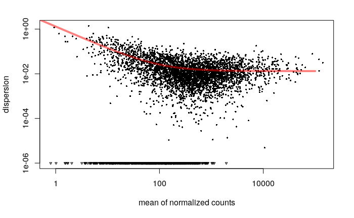

```r
plotDispEsts(cds) # Gives the fitted dispersion vs normalized mean to see fit
```

```r
results = nbinomTest(cds,"0h","24h") # Calculate logfoldchange and adj p-values
install.packages("farver")
#write.csv(results, file = "differential_expression_results_0h_24h.csv") # Save output
significant_genes_0h_24h = results[results$padj < cutoff,] # Significant genes
```

Where the plotDispEsts gives an approximate fit of the modelled data to our input data.

Haven gotten and saved all the significant genes, these were further analysed after sorting them according to the code seen below. At last, table with the significant gens and their output log2FCs and padjusted etc are saved as a text file.

```r
# Sort according to p-adj
order_0h_30min = order(significant_genes_0h_30min$padj)
order_0h_6h = order(significant_genes_0h_6h$padj)
order_0h_24h = order(significant_genes_0h_24h$padj)

significant_genes_0h_30min = significant_genes_0h_30min[order_0h_30min,]
significant_genes_0h_6h = significant_genes_0h_6h[order_0h_6h,]
significant_genes_0h_24h = significant_genes_0h_24h[order_0h_24h,]

# Finding specific genes
#significant_genes_0h_30min[significant_genes_0h_30min$id=="sifB",]$log2FoldChange

# Save the results to use in the metabollic profiling step
write.table(significant_genes_0h_30min, file ="~/Johannas_Rcode/results/differential_expression_results/significant_genes_30min", sep = "\t" )
write.table(significant_genes_0h_6h, file ="~/Johannas_Rcode/results/differential_expression_results/significant_genes_6h", sep = "\t" )
write.table(significant_genes_0h_24h, file ="~/Johannas_Rcode/results/differential_expression_results/significant_genes_24h", sep = "\t" )
```

# Testing something new DESEq, find differentially expressed genes

# Normalize all counts in a common matrix,

# get only 1 value of baseMean for time = 0h

```r
# TODO: is the filtering false default?

# FDR cutoff
cutoff = 0.05

counts_large_df = cbind(counts_0h,counts_30min,counts_6h,counts_24h)
times = factor(c("0h","0h","0h","30min","30min","30min","6h","6h","6h","24h","24h","24h")) # The conditions
cds = newCountDataSet(counts_large_df,times) # Data structure for DESeq
cds = estimateSizeFactors(cds) # Normalization
cds = estimateDispersions(cds) # Estimate dispersion

# Filtering (not used here)
#rs = rowSums(counts(cds))
#theta = 0.4
#use = (rs>quantile(rs,probs=theta))
#cdsFilt = cds[use,]
# use cdsFilt for nbinomTest()

# time = 0h vs time = 30min
results = nbinomTest(cds, "0h","30min") # Calculate logfoldchange and p-values
#write.csv( results, file="differential_expression_results_0h_30min.csv" ) # Save output
common_BaseMeanA_significant_genes_0h_30min = results[results$padj < cutoff,] # Significant genes

# time = 0h vs time = 6h
results = nbinomTest(cds, "0h","6h") # Calculate logfoldchange and adj p-values
#write.csv( results, file="differential_expression_results_0h_6h.csv" ) # Save output
common_BaseMeanA_significant_genes_0h_6h = results[results$padj < cutoff,] # Signicicant genes

# time = 0h vs time = 24h
results = nbinomTest(cds,"0h","24h") # Calculate logfoldchange and adj p-values
#write.csv(results, file = "differential_expression_results_0h_24h.csv") # Save output
common_BaseMeanA_significant_genes_0h_24h = results[results$padj < cutoff,] # Significant genes

# Sort according to p-adj
common_BaseMeanA_order_0h_30min = order(common_BaseMeanA_significant_genes_0h_30min$padj)
common_BaseMeanA_order_0h_6h = order(common_BaseMeanA_significant_genes_0h_6h$padj)
common_BaseMeanA_order_0h_24h = order(common_BaseMeanA_significant_genes_0h_24h$padj)

common_BaseMeanA_significant_genes_0h_30min = common_BaseMeanA_significant_genes_0h_30min[common_BaseMeanA_order_0h_30min,]
common_BaseMeanAsignificant_genes_0h_6h = common_BaseMeanA_significant_genes_0h_6h[common_BaseMeanA_order_0h_6h,]
common_BaseMeanA_significant_genes_0h_24h = common_BaseMeanA_significant_genes_0h_24h[common_BaseMeanA_order_0h_24h,]

# Finding specific genes
#significant_genes_0h_30min[significant_genes_0h_30min$id=="sifB",]$log2FoldChange


# Create new tables for the significant genes which have been processed together
write.table(common_BaseMeanA_significant_genes_0h_30min, file ="~/Johannas_Rcode/results/differential_expression_results/common_BaseMeanA_significant_genes_30min", sep = "\t" )
write.table(common_BaseMeanA_significant_genes_0h_6h, file ="~/Johannas_Rcode/results/differential_expression_results/common_BaseMeanAsignificant_genes_6h", sep = "\t" )
write.table(common_BaseMeanA_significant_genes_0h_24h, file ="~/Johannas_Rcode/results/differential_expression_results/common_BaseMeanAsignificnt_genes_24h", sep = "\t" )
```

# Create list of gene names and use in Venn diagramme

To access what genes were commonly differentially expressed at all time points, a venn diagramme was created.

```r
# Extract only the GeneIDs
genelist_30min = as.character(significant_genes_0h_30min$id)
genelist_6h = as.character(significant_genes_0h_6h$id)
genelist_24h = as.character(significant_genes_0h_24h$id)


myCol <- brewer.pal(3, "Pastel2")

# Chart where overlap between geneIDs are searched for
venn.diagram(
        x = list(genelist_30min, genelist_6h, genelist_24h),
        category.names = c("30 min" , "6h " , "24h"),
        filename = '~/Johannas_Rcode/results/differential_expression_results/VennDiagram.png',
        output=TRUE,

        # Output features
        imagetype="png" ,
        height = 480 ,
        width = 480 ,
        resolution = 300,
        compression = "lzw",

        # Circles
        lwd = 2,
        lty = 'blank',
        fill = myCol,

        # Numbers
        cex = .6,
        fontface = "bold",
        fontfamily = "sans",

        # Set names
        cat.cex = 0.6,
        cat.fontface = "bold",
        cat.default.pos = "outer",
        cat.pos = c(-27, 27, 135),
        cat.dist = c(0.055, 0.055, 0.085),
        cat.fontfamily = "sans",
        rotation = 1
)
```

```
[1] 1
```

# REMOVE UPON DECISION - Venn for common basemeanA

# Venn diagrammes

## Create list of gene names

```r
# Create list of GeneIDs
common_BaseMeanA_genelist_30min = as.character(common_BaseMeanA_significant_genes_0h_30min$id)
common_BaseMeanA_genelist_6h = as.character(common_BaseMeanA_significant_genes_0h_6h$id)
common_BaseMeanA_genelist_24h = as.character(common_BaseMeanA_significant_genes_0h_24h$id)


myCol <- brewer.pal(3, "Pastel2")

# Chart where overlap between geneIDs are searched for
venn.diagram(
        x = list(common_BaseMeanA_genelist_30min, common_BaseMeanA_genelist_6h, common_BaseMeanA_genelist_24h),
        category.names = c("30 min" , "6h " , "24h"),
        filename = '~/Johannas_Rcode/results/differential_expression_results/VennDiagram_common.png',
        output=TRUE,

        # Output features
        imagetype="png" ,
        height = 480 ,
        width = 480 ,
        resolution = 300,
        compression = "lzw",

        # Circles
        lwd = 2,
        lty = 'blank',
        fill = myCol,

        # Numbers
        cex = .6,
        fontface = "bold",
        fontfamily = "sans",

        # Set names
        cat.cex = 0.6,
        cat.fontface = "bold",
        cat.default.pos = "outer",
        cat.pos = c(-27, 27, 135),
        cat.dist = c(0.055, 0.055, 0.085),
        cat.fontfamily = "sans",
        rotation = 1
)
```

```
[1] 1
```

# Dot plot - original values

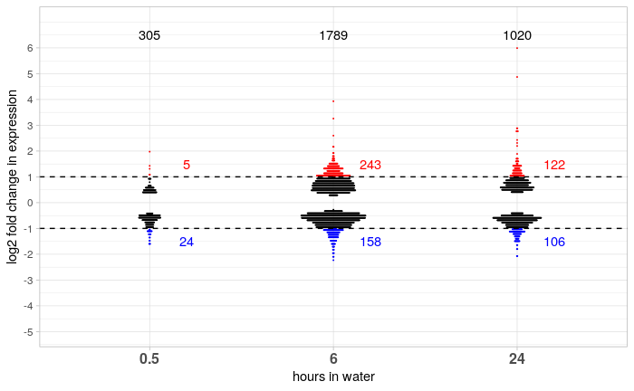

```r
# Larger than 1 or lower than -1
high_0h_30min = sum(significant_genes_0h_30min$log2FoldChange > 1)
low_0h_30min = sum(significant_genes_0h_30min$log2FoldChange < (-1))

high_0h_6h = sum(significant_genes_0h_6h$log2FoldChange > 1)
low_0h_6h = sum(significant_genes_0h_6h$log2FoldChange < (-1))

high_0h_24h = sum(significant_genes_0h_24h$log2FoldChange > 1)
low_0h_24h = sum(significant_genes_0h_24h$log2FoldChange < (-1))

# Ratios reference
ratio_ref_0h_30min = 8/28
ratio_ref_0h_6h = 271/155
ratio_ref_0h_24h = 148/112

# Ratios our
ratio_our_0h_30min = high_0h_30min/low_0h_30min
ratio_our_0h_6h = high_0h_6h / low_0h_6h
ratio_our_0h_24h = high_0h_24h / low_0h_24h

# Dot plot
logfold_30min = data.frame(group = "0.5",
                           value = significant_genes_0h_30min$log2FoldChange)
logfold_6h = data.frame(group="6", value = significant_genes_0h_6h$log2FoldChange)
logfold_24h = data.frame(group="24",value=significant_genes_0h_24h$log2FoldChange)
plot.data = rbind(logfold_30min, logfold_6h, logfold_24h)
plot.data$colors = 0
plot.data[which(plot.data$value < (-1)),"colors"] = -1
plot.data[which( plot.data$value > 1),"colors"] = 1
plot.data$colors = as.factor(plot.data$colors)

# Number of observations in each dot plot
n_fun <- function(x){
  return(data.frame(y = 6.5,
                    label = length(x)))
}

# Number of observations > 1 in each dot plot
n_fun_high <- function(x){
  return(data.frame(y = 1.5,
                    label = length(x[ x > 1])))
}

# Number of observations < (-1) in each dot plot
n_fun_low <- function(x){
  return(data.frame(y = -1.5,
                    label = length(x[ x <(-1)])))
}
# Plot it
p = ggplot(plot.data, aes(x=group, y=value)) +
  geom_dotplot(binaxis='y', stackdir='center',binwidth = 0.09,dotsize = 0.2, aes(color=colors)) +
  xlab("hours in water") + scale_y_continuous(name="log2 fold change in expression", breaks=seq(-5,6,1),limits=c(-5,7)) +
  geom_hline(yintercept=1,linetype="dashed",size=0.5) + geom_hline(yintercept=-1,linetype="dashed",size=0.5) +
  theme_light() + scale_color_manual(values=c("blue", "black", "red")) + guides(color=FALSE) +
    stat_summary(fun.data = n_fun, geom = "text") + stat_summary(aes(x = as.numeric(group) + 0.2),fun.data = n_fun_high, geom = "text",color="red") +
  stat_summary(aes(x = as.numeric(group) + 0.2),fun.data = n_fun_low, geom = "text",color ="blue") +
  theme(axis.text.x=element_text(size=12,face="bold"))
p
```

# Remove this later once we have decided which values to use!!! - values with common normalization

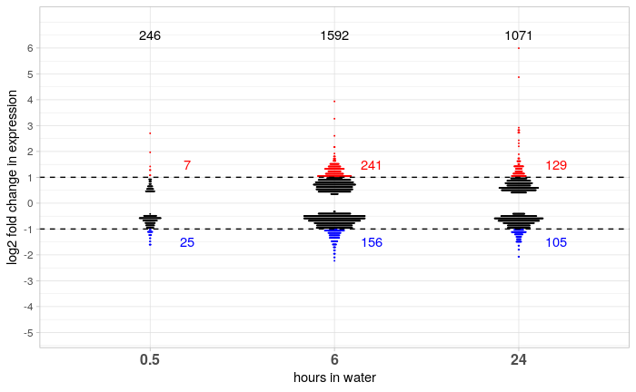

```r
# Larger than 1 or lower than -1
common_BaseMeanA_high_0h_30min = sum(common_BaseMeanA_significant_genes_0h_30min$log2FoldChange > 1)
common_BaseMeanA_low_0h_30min = sum(common_BaseMeanA_significant_genes_0h_30min$log2FoldChange < (-1))

common_BaseMeanA_high_0h_6h = sum(common_BaseMeanA_significant_genes_0h_6h$log2FoldChange > 1)
common_BaseMeanA_low_0h_6h = sum(common_BaseMeanA_significant_genes_0h_6h$log2FoldChange < (-1))

common_BaseMeanA_high_0h_24h = sum(common_BaseMeanA_significant_genes_0h_24h$log2FoldChange > 1)
common_BaseMeanA_low_0h_24h = sum(common_BaseMeanA_significant_genes_0h_24h$log2FoldChange < (-1))

# Ratios reference
common_BaseMeanA_ratio_ref_0h_30min = 8/28
common_BaseMeanA_ratio_ref_0h_6h = 271/155
common_BaseMeanA_ratio_ref_0h_24h = 148/112

# Ratios our
common_BaseMeanA_ratio_our_0h_30min = common_BaseMeanA_high_0h_30min/common_BaseMeanA_low_0h_30min
common_BaseMeanA_ratio_our_0h_6h = common_BaseMeanA_high_0h_6h /common_BaseMeanA_low_0h_6h
common_BaseMeanA_ratio_our_0h_24h = common_BaseMeanA_high_0h_24h / common_BaseMeanA_low_0h_24h

# Dot plot
common_BaseMeanA_logfold_30min = data.frame(group = "0.5",
                           value = common_BaseMeanA_significant_genes_0h_30min$log2FoldChange)
common_BaseMeanA_logfold_6h = data.frame(group="6", value = common_BaseMeanA_significant_genes_0h_6h$log2FoldChange)
common_BaseMeanA_logfold_24h = data.frame(group="24",value=common_BaseMeanA_significant_genes_0h_24h$log2FoldChange)
plot.data = rbind(common_BaseMeanA_logfold_30min, common_BaseMeanA_logfold_6h, common_BaseMeanA_logfold_24h)
plot.data$colors = 0
plot.data[which(plot.data$value < (-1)),"colors"] = -1
plot.data[which( plot.data$value > 1),"colors"] = 1
plot.data$colors = as.factor(plot.data$colors)

# Number of observations in each dot plot
n_fun <- function(x){
  return(data.frame(y = 6.5,
                    label = length(x)))
}

# Number of observations > 1 in each dot plot
n_fun_high <- function(x){
  return(data.frame(y = 1.5,
                    label = length(x[ x > 1])))
}

# Number of observations < (-1) in each dot plot
n_fun_low <- function(x){
  return(data.frame(y = -1.5,
                    label = length(x[ x <(-1)])))
}
# Plot it
p = ggplot(plot.data, aes(x=group, y=value)) +
  geom_dotplot(binaxis='y', stackdir='center',binwidth = 0.09,dotsize = 0.2, aes(color=colors)) +
  xlab("hours in water") + scale_y_continuous(name="log2 fold change in expression", breaks=seq(-5,6,1),limits=c(-5,7)) +
  geom_hline(yintercept=1,linetype="dashed",size=0.5) + geom_hline(yintercept=-1,linetype="dashed",size=0.5) +
  theme_light() + scale_color_manual(values=c("blue", "black", "red")) + guides(color=FALSE) +
    stat_summary(fun.data = n_fun, geom = "text") + stat_summary(aes(x = as.numeric(group) + 0.2),fun.data = n_fun_high, geom = "text",color="red") +
  stat_summary(aes(x = as.numeric(group) + 0.2),fun.data = n_fun_low, geom = "text",color ="blue") +
  theme(axis.text.x=element_text(size=12,face="bold"))
p
```